# Assignment3

Goup5

24 April 2018

## Loading the data:

```r
library(tidyverse)
library(broom)
houses <- read_csv("data/Melbourne_housing_FULL.csv")
```

This was provided as part of the assignment properties. Warnings have been put to false so that the graphs presented can be seen clearly and the visual representations are clear.

## Collecting certain variables into a new data frame:

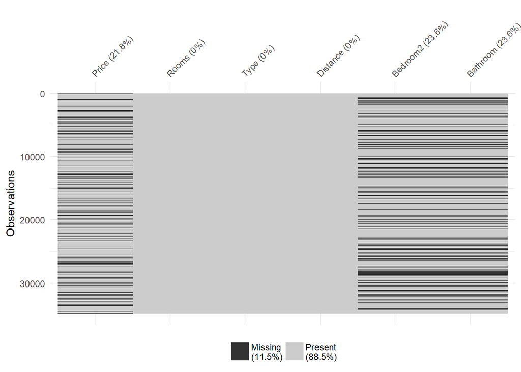

```r
new_houses <- houses %>%
  select(Price, Rooms, Type, Distance, Bedroom2, Bathroom)

library(visdat)
vis_miss(new_houses)
```

```r
colSums(is.na(new_houses))
```

```
##    Price    Rooms     Type Distance Bedroom2 Bathroom
##     7610        0        0        1     8217     8226
```

Firstly using the select method, the necessary variables are placed into a new data frame: new_houses. Next vis_miss method and colSums method are applied so shocase the summary of missing values. Values are missing in variables: Price, Distance, Bedroom2 and Bathroom, and number of missing variables is also presented.

## Missing values summary and strategy for dealing with them:

```r
rooms_calculation <- new_houses %>%
  mutate(special = Bedroom2 + Bathroom)

rooms_changing <- rooms_calculation %>%
  mutate(
    Rooms = if_else(
      Rooms < !is.na(special), special, Rooms
    ))

new_houses1 <- rooms_changing %>%
  select(Price, Rooms, Type, Distance, Bedroom2, Bathroom)

names(new_houses1)[2] <- "TotalRooms"
names(new_houses1)[5] <- "Bedrooms"

# Price, TotalRooms, Type, Distance, Bedrooms, Bathroom

imputed_houses <- new_houses1 %>%
  filter(!is.na(Price)) %>%
  mutate(
    Distance = if_else(
      is.na(Distance), mean(Distance, na.rm = TRUE), Distance
    ),
    Bedrooms = if_else(
      is.na(Bedrooms), as.integer(median(Bedrooms, na.rm = TRUE)), Bedrooms
    ),
    Bathroom = if_else(
      is.na(Bathroom), as.integer(median(Bathroom, na.rm = TRUE)), Bathroom
    ))

colSums(is.na(imputed_houses))
```

```
##      Price TotalRooms       Type   Distance   Bedrooms   Bathroom
##          0          0          0          0          0          0
```

Firstly, a new variable: special had to be created, which is the sum of the bedroom2 and bathroom variable. Then special was compared with the Rooms variable, since some observations had less total rooms than the sum of bedroom2 and bathroom, which is illogical. Next all observations where Price was a missing value, was deleted from the data frame. This is because if the response variable is not present, the model would not work properly. Lastly, missing distance values were replaced with the mean distance (since it can be a double), and the bedrooms and bathroom were replaced with median bedrooms and bathrooms respectively, as they just be whole number - you cannot have half rooms by appling means. Lastly, again applying colSums, it can be seen that now there are no missing values in the imputed_houses data frame - so models can be developed.

## Plots to summarise relationship between price:

#### The Impact of Type of Housing on Pricing

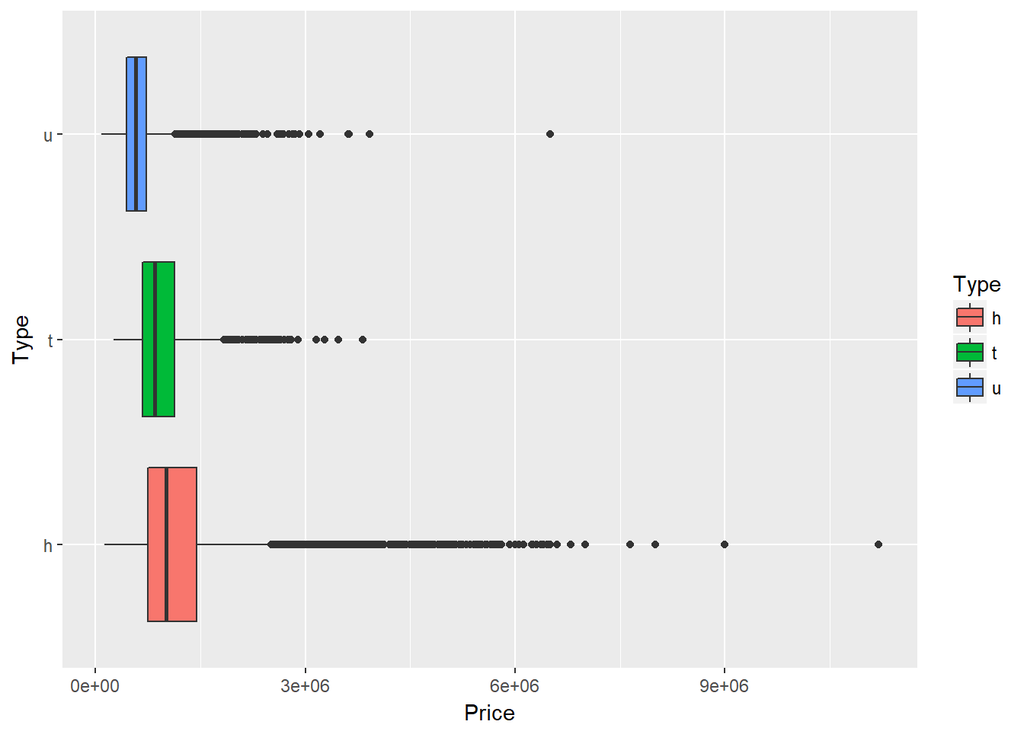

```r
ggplot(data = imputed_houses, aes(x = Type, y = Price)) +
  geom_boxplot(aes(fill = Type)) +
  coord_flip()
```

#### The Impact of Total number of Rooms on Pricing

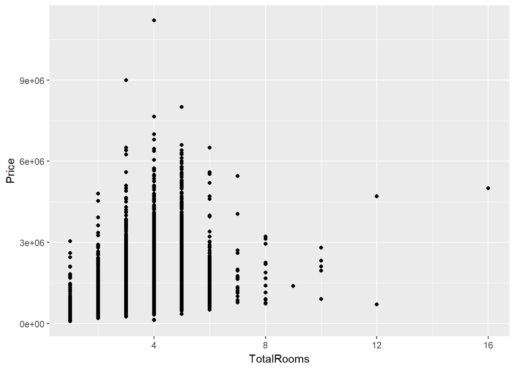

```r
ggplot(data = imputed_houses) +
  geom_point(mapping = aes(x = TotalRooms, y = Price))
```

There is a relative bell curve shape to this graph. As total rooms increases, so does the price. As expected, there is a majority in the centre where the amount of rooms and the price peaks, then as the total rooms increases, there is a dip. This is expected, as there is less need for more rooms. There are some houses with many rooms and close to the price of the average, however, these are outliers and cannot be expected from all houses.

#### The Impact of Distance from CBD on Pricing

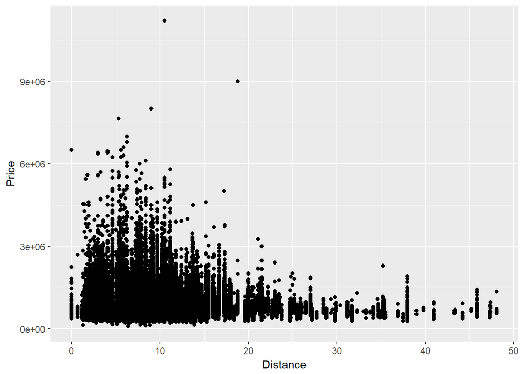

```r
ggplot(data = imputed_houses) +
  geom_point(mapping = aes(x = Distance, y = Price))
```

There is a clear trend in this graph with the data showing heavy positive skewing.There is a clear majority when there is a smaller distance, with greater house prices. As the distance gets larger, the house prices go down. This makes sense as those who are from overseas or looking to move out of home and buy a new house may be inclined to try and purchase towards the city. Also, there are only small amount of houses that have 0 distance (in the heart of the cbd) this is most likely caused by not being able to build primarily in the city.

#### The Impact of number of Bedrroms on Pricing

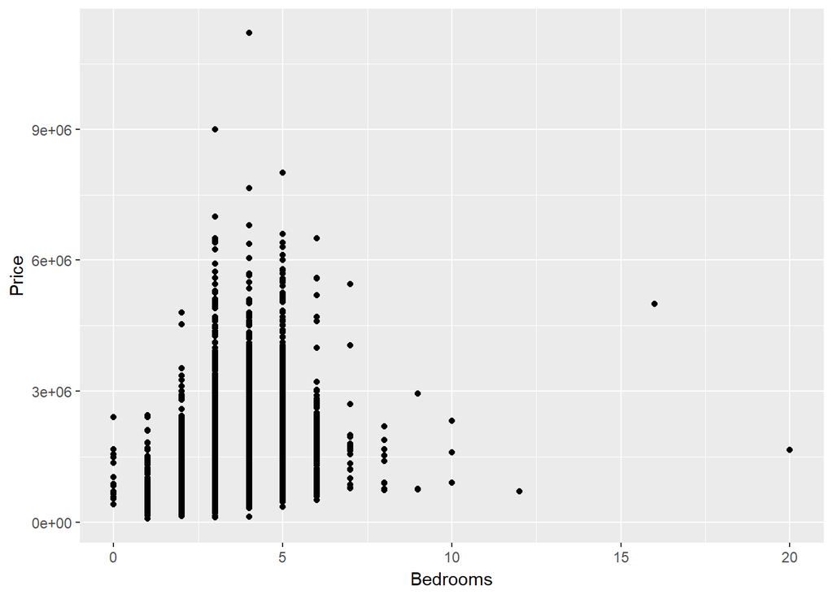

```r
ggplot(data = imputed_houses) +
  geom_point(mapping = aes(x = Bedrooms, y = Price))
```

There is a bell-curve trend in this graph, with the data being normally distributed. As the bedrooms increase, so does the price. Howeverm likewise to the other graph, there are outliers with 15+ and 20 bedrooms. This is probably because 20 rooms is excessive, however the price of this house is cheaper than some of the houses with less bedrooms and hence better value.

#### The Impact of number of Bathrooms on Pricing

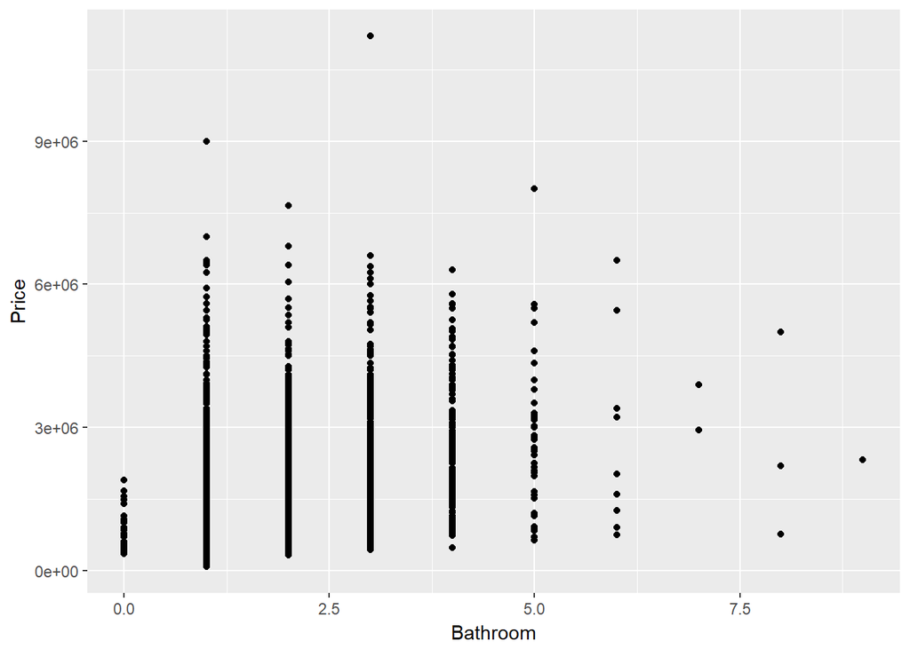

```r
ggplot(data = imputed_houses) +
  geom_point(mapping = aes(x = Bathroom, y = Price))
```

There is no clear pattern to this trend. It is mostly randomly scattered and no definitive skewness. It seems as if most of the variables are randomly mixed and the amount of bathrooms has no clear indication of house price.

## Model and justification for choices of transforamtions, variable selection and interactions:

### Model 1

```r
imputed_houses <- imputed_houses %>%
  mutate(
    l_distance = log10(Distance + 1),
    l_price = log10(Price)
  )

Model1_fita <- lm(l_price ~ l_distance+I(l_distance^2), data = imputed_houses)
tidy(Model1_fita)
```

```
##              term   estimate  std.error statistic       p.value
## 1     (Intercept)  5.7785003 0.01428033 404.64747  0.000000e+00
## 2      l_distance  0.5887544 0.02913759  20.20600  3.971345e-90
## 3 I(l_distance^2) -0.3804237 0.01465397 -25.96046 8.466451e-147
```

```r
glance(Model1_fita)
```

```
##    r.squared adj.r.squared     sigma statistic       p.value df   logLik
## 1 0.05142825    0.05135862 0.2186757  738.5373 4.467498e-313  3 2759.633
##         AIC       BIC deviance df.residual
## 1 -5511.266 -5478.415 1302.782       27244
```

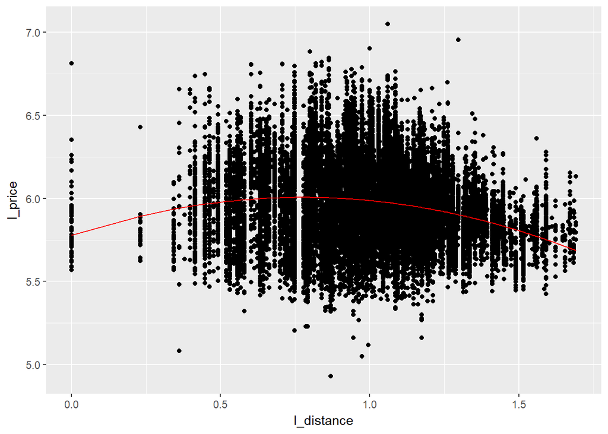

```r
dis_mod1 <- augment(Model1_fita, imputed_houses)

ggplot(dis_mod1, aes(x = l_distance, y = l_price)) +
  geom_point() +
  geom_line(aes(y = .fitted), colour = "red")
```

### Model 2

```r
Model1_fitb <- lm(l_price ~ Type, data = imputed_houses)
tidy(Model1_fitb)
```

```
##          term    estimate   std.error  statistic       p.value
## 1 (Intercept)  6.02614238 0.001452756 4148.07553  0.000000e+00
## 2       Typet -0.08935887 0.003963980  -22.54271 1.659823e-111
## 3       Typeu -0.26298179 0.002950948  -89.11774  0.000000e+00
```

```r
glance(Model1_fitb)
```

```
##   r.squared adj.r.squared     sigma statistic p.value df   logLik
## 1 0.2266633     0.2266066 0.1974466  3992.579       0  3 5542.137
##         AIC       BIC deviance df.residual
## 1 -11076.27 -11043.42 1062.112       27244
```

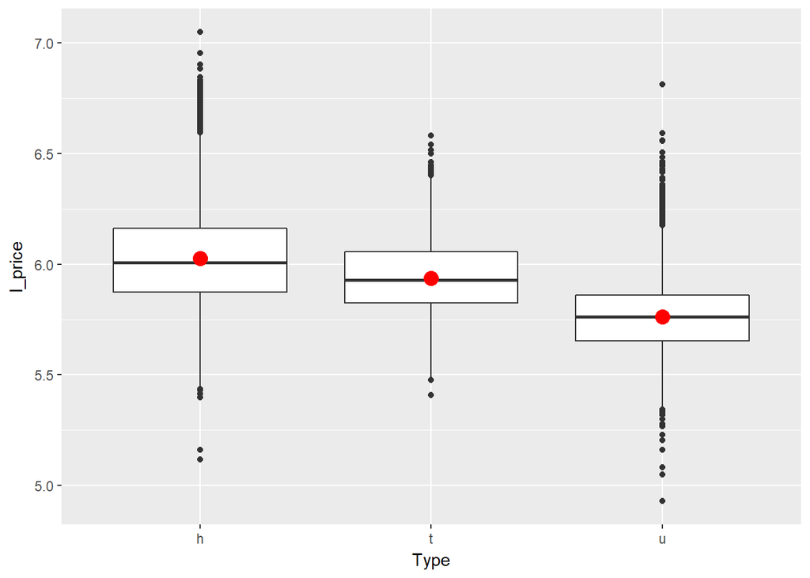

```r
dis_mod2 <- augment(Model1_fitb, imputed_houses)

ggplot(dis_mod2, aes(x = Type, y = l_price)) +
  geom_boxplot() +
  geom_point(aes(y = .fitted), colour = "red", size = 4)
```

### Model 3

```r
Model1_fitc <- lm(l_price ~ l_distance*Type + I(l_distance^2), data = imputed_houses)
tidy(Model1_fitc)
```

```
##               term    estimate  std.error  statistic       p.value
## 1      (Intercept)  6.31856137 0.01506381 419.453029  0.000000e+00
## 2       l_distance -0.09594591 0.02843228  -3.374541  7.404195e-04
## 3            Typet -0.40370019 0.01887100 -21.392620 1.056134e-100
## 4            Typeu -0.61820670 0.01171565 -52.767599  0.000000e+00
## 5  I(l_distance^2) -0.15958623 0.01343285 -11.880294  1.802483e-32
## 6 l_distance:Typet  0.28695388 0.01802555  15.919284  8.404217e-57
## 7 l_distance:Typeu  0.32074764 0.01196375  26.809959 2.646142e-156
```

```r
glance(Model1_fitc)
```

```
##   r.squared adj.r.squared     sigma statistic p.value df  logLik       AIC
## 1 0.3619441     0.3618035 0.1793604  2575.364       0  7 8161.78 -16307.56
##         BIC deviance df.residual
## 1 -16241.86 876.3153       27240
```

[figure not shown]

```r
dis_mod3 <- augment(Model1_fitb, imputed_houses)

Final_model <- ggplot(dis_mod3, aes(x = l_distance, y = l_price)) +
  geom_point() +
  geom_line(aes(y = .fitted), colour = "red") +
  facet_wrap(~ Type)

Final_model
```

## Final model summary and why it is the most suitable:

```r
tidy(Model1_fitc)
```

```
##               term    estimate  std.error  statistic       p.value
## 1      (Intercept)  6.31856137 0.01506381 419.453029  0.000000e+00
## 2       l_distance -0.09594591 0.02843228  -3.374541  7.404195e-04
## 3            Typet -0.40370019 0.01887100 -21.392620 1.056134e-100
## 4            Typeu -0.61820670 0.01171565 -52.767599  0.000000e+00
## 5  I(l_distance^2) -0.15958623 0.01343285 -11.880294  1.802483e-32
## 6 l_distance:Typet  0.28695388 0.01802555  15.919284  8.404217e-57
## 7 l_distance:Typeu  0.32074764 0.01196375  26.809959 2.646142e-156
```

```r
glance(Model1_fitc)
```

```
##   r.squared adj.r.squared     sigma statistic p.value df  logLik       AIC
## 1 0.3619441     0.3618035 0.1793604  2575.364       0  7 8161.78 -16307.56
##         BIC deviance df.residual
## 1 -16241.86 876.3153       27240
```

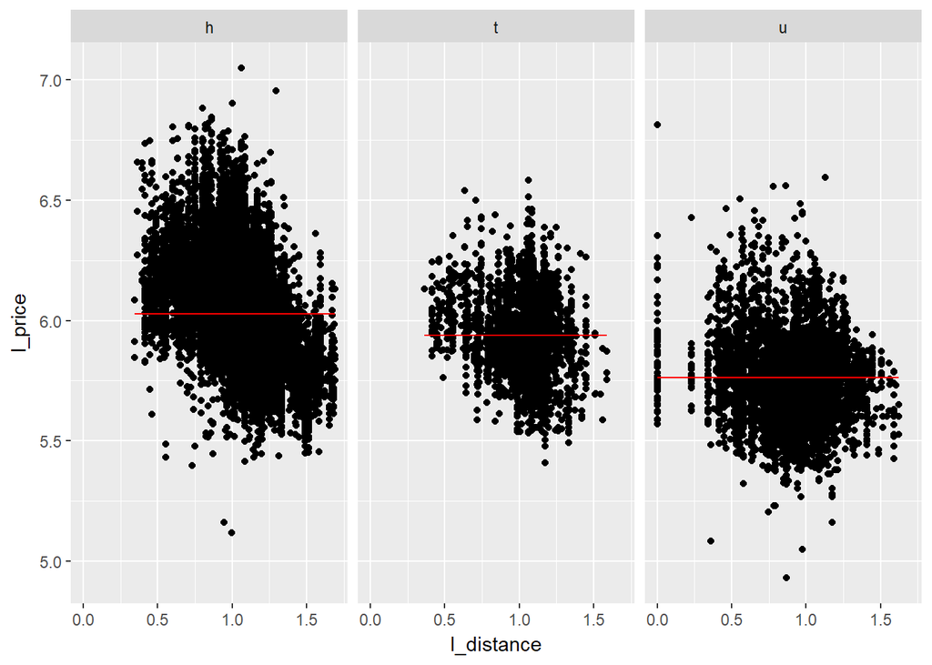

```r
Final_model
```

We decided to choose Model 3 as our final model as it best expressed that data for Melbourne housing. Additionally, this model’s coefficients show that they are helping predict that data and make sense of the assumptions held. This model has the highest r squared at 36.18%, while still describing a proportion of the possible relationship. The main reason why we did not choose model1 and model2, what primarily because they are basic models and as a result don’t take into account the different variables that could also impact the price. however with model3, the interaction between distance and type of property is taken into account, and shown to be useful in terms of adjusted r squared, p value and deviance statistics.